# How many templates does the benchmark need?

Sample-size ablation, original vs symbolic

Two questions a reviewer will ask, which have different answers:

1. **Would more templates change which model looks best?** Measured as the rank correlation between a $k$-template ordering of the models and the full 100-template ordering.
2. **Would more templates change the reported accuracies?** Measured as the standard error of a model’s score at a budget of $k$ templates.

The second is the one that speaks to whether 100 is enough, and it is where the two splits separate. A template is the unit you pay to translate and validate; the *original* split gives one instance per template, the *symbolic* split gives twenty. So at an equal translation budget the symbolic split buys twenty times the observations, and the question is how much precision that actually returns.

```r
EXCLUDED_LANGUAGES <- c("eng_metric", "uncorrected_isl", "nob")
## Read straight from the parquet, so the exclusions in transfer_analysis.Rmd do
## not apply automatically and are repeated here. The two runs below sit at the
## probability floor (0.28% and 0.40% accuracy) and carry no information.
## NOTE the naming: in the parquet the reasoning-ON run carries the BARE name
## ("Qwen3.5-0.8B") and only the off-variant is suffixed. transfer_analysis.Rmd
## adds the "(reasoning on)" suffix afterwards, so a document reading the parquet
## must exclude the bare name or it silently keeps the model.
EXCLUDED_RUNS <- c("gpt-5.4-nano", "Qwen3.5-0.8B", "EuroLLM-1.7B-Instruct")

cells <- read_parquet("../../artifacts/transfer_tables/analysis.parquet") %>%
  select(source_id, language, correct, model, split, task) %>%
  filter(grepl("@refs/pr/16/", task, fixed = TRUE),
         !language %in% EXCLUDED_LANGUAGES,
         !model %in% EXCLUDED_RUNS) %>%
  group_by(split, model, language, template = source_id) %>%
  summarise(n_correct = sum(correct), n_total = n(), .groups = "drop") %>%
  mutate(acc = n_correct / n_total)

cat("models:", n_distinct(cells$model), "| languages:", n_distinct(cells$language),
    "| templates:", n_distinct(cells$template), "\n")
```

```
## models: 46 | languages: 15 | templates: 100
```

```r
cells %>% count(split, n_total) %>% rename(instances_per_template = n_total, cells = n)
```

```
## # A tibble: 2 × 3
##   split     instances_per_template cells
##   <chr>                      <int> <int>
## 1 original                       1 69000
## 2 synthetic                     20 69000
```

# Precision: the standard error at a template budget

The relevant population is *possible templates*, not the 100 we happen to have — the question is whether a different draw of templates would give a different answer. So the standard error at a budget of $k$ templates is the template-to- template standard deviation divided by $\sqrt{k}$, with no finite-population correction. That also makes the curve extrapolable past 100, which is exactly what “would more samples help” needs.

```r
KS <- c(10, 20, 50, 75, 100)
NS <- c(1, 2, 5, 10, 20)   # instances per template, for the symbolic series

## template-to-template SD of accuracy, within each (split, model, language)
sd_tpl <- cells %>% group_by(split, model, language) %>%
  summarise(sd_template = sd(acc), .groups = "drop")

se <- sd_tpl %>%
  tidyr::crossing(k = KS) %>%
  mutate(se_pp = 100 * sd_template / sqrt(k)) %>%
  group_by(split, k) %>%
  summarise(se_pp = mean(se_pp), .groups = "drop")
```

```r
se %>% pivot_wider(names_from = split, values_from = se_pp) %>%
  mutate(across(where(is.numeric), ~round(., 2)),
         ratio = round(original / synthetic, 2)) %>%
  rename(templates = k)
```

```
## # A tibble: 5 × 4
##   templates original synthetic ratio
##       <dbl>    <dbl>     <dbl> <dbl>
## 1        10    10.8       7.41  1.46
## 2        20     7.64      5.24  1.46
## 3        50     4.84      3.31  1.46
## 4        75     3.95      2.7   1.46
## 5       100     3.42      2.34  1.46
```

```r
## How many original templates match 100 symbolic ones? SE scales as 1/sqrt(k),
## so the equivalent budget is k * (sd_original / sd_synthetic)^2.
r <- sd_tpl %>% group_by(split) %>% summarise(s = mean(sd_template), .groups = "drop")
ratio2 <- (r$s[r$split == "original"] / r$s[r$split == "synthetic"])^2
cat(sprintf("template-level SD: original %.4f, symbolic %.4f\n",
            r$s[r$split == "original"], r$s[r$split == "synthetic"]))
```

```
## template-level SD: original 0.3419, symbolic 0.2342
```

```r
cat(sprintf("one symbolic template is worth %.1f original ones for precision;\n", ratio2))
```

```
## one symbolic template is worth 2.1 original ones for precision;
```

```r
cat(sprintf("matching 100 symbolic templates would need %.0f original templates\n", 100 * ratio2))
```

```
## matching 100 symbolic templates would need 213 original templates
```

# Ranking: does the ordering of models settle?

```r
R <- 40
set.seed(20260916)
tpls <- unique(cells$template)

## Reference ordering: the best estimate available, i.e. all 100 templates at the
## full 20 instances. Every curve is scored against the same reference so the
## instance budgets are comparable to each other and to the original split.
ref <- cells %>% filter(split == "synthetic") %>%
  group_by(language, model) %>%
  summarise(full = sum(n_correct) / sum(n_total), .groups = "drop")

rank_one <- function(series, nn, k, r) {
  d <- if (series == "Original") {
    cells %>% filter(split == "original")
  } else {
    x <- cells %>% filter(split == "synthetic")
    x$n_correct <- if (nn == 20) x$n_correct else
      rhyper(nrow(x), x$n_correct, 20 - x$n_correct, nn)
    x$n_total <- nn
    x
  }
  S <- sample(tpls, k)
  d %>% filter(template %in% S) %>%
    group_by(language, model) %>%
    summarise(sub = sum(n_correct) / sum(n_total), .groups = "drop") %>%
    inner_join(ref, by = c("language", "model")) %>%
    group_by(language) %>%
    summarise(rho = cor(sub, full, method = "spearman"), .groups = "drop") %>%
    mutate(series = series, k = k, rep = r)
}
grid <- bind_rows(
  tidyr::crossing(series = sprintf("Symbolic, %d", NS), k = KS, rep = seq_len(R)) %>%
    mutate(nn = as.integer(sub("Symbolic, ", "", series))),
  tidyr::crossing(series = "Original", k = KS, rep = seq_len(R)) %>% mutate(nn = 1L))
rank_res <- bind_rows(Map(rank_one, grid$series, grid$nn, grid$k, grid$rep))
```

```r
rank_res %>% group_by(series, k) %>%
  summarise(spearman = round(mean(rho), 4), .groups = "drop") %>%
  pivot_wider(names_from = series, values_from = spearman) %>%
  rename(templates = k)
```

```
## # A tibble: 5 × 7
##   templates Original `Symbolic, 1` `Symbolic, 10` `Symbolic, 2` `Symbolic, 20`
##       <dbl>    <dbl>         <dbl>          <dbl>         <dbl>          <dbl>
## 1        10    0.891         0.905          0.954         0.926          0.962
## 2        20    0.935         0.936          0.974         0.953          0.977
## 3        50    0.967         0.966          0.988         0.976          0.992
## 4        75    0.974         0.975          0.994         0.984          0.996
## 5       100    0.979         0.980          0.998         0.989          1
## # ℹ 1 more variable: `Symbolic, 5` <dbl>
```

Every series is scored against the same reference — all 100 templates at the full 20 instances — so the columns are comparable to each other. A column does not reach exactly 1 at $k = 100$ unless it *is* the reference, which is why only the 20-instance symbolic column does.

# How many instances per template?

The benchmark generates 20 symbolic instances from each template, and 20 turns out to be comfortably enough. The figure below shows the budgets converging with sharply diminishing returns, and the decomposition says why they must: the across-template variance splits into a part more instances remove and a part they cannot.

$$\mathrm{Var}(\hat p) \;=\;
\sigma^2_{\text{template}} \;+\; \mathbb{E}[q(1-q)]/n$$

Only the second term depends on $n$. Anything that averages out with more instances — including systematic difficulty differences *between* instantiations of the same template — scales as $1/n$ and lands there by construction; $\sigma^2_{\text{template}}$ is the spread of true difficulty across templates, which no amount of resampling touches.

Both terms are estimable from the $n = 20$ data alone, with no extrapolation: for $n$ draws at rate $q$, $\mathbb{E}[\hat p(1-\hat p)] = q(1-q)(1 - 1/n)$.

```r
per_cell <- cells %>% filter(split == "synthetic") %>%
  group_by(model, language) %>%
  summarise(var_phat = var(acc),
            Eq1q = mean(acc * (1 - acc) * n_total / (n_total - 1)),
            n = first(n_total), .groups = "drop") %>%
  mutate(sigma_t2 = var_phat - Eq1q / n)

tibble(quantity = c("Var across templates", "binomial term at n = 20",
                    "template-level (by subtraction)"),
       value = c(mean(per_cell$var_phat), mean(per_cell$Eq1q) / 20,
                 mean(per_cell$sigma_t2))) %>%
  mutate(value = round(value, 5),
         share = round(100 * value / value[1], 1))
```

```
## # A tibble: 3 × 3
##   quantity                          value share
##   <chr>                             <dbl> <dbl>
## 1 Var across templates            0.0609  100
## 2 binomial term at n = 20         0.00405   6.7
## 3 template-level (by subtraction) 0.0568   93.4
```

```r
share <- mean(per_cell$sigma_t2) / mean(per_cell$var_phat)
cat(sprintf("template-level share of the variance at n = 20: %.0f%%\n", 100 * share))
```

```
## template-level share of the variance at n = 20: 93%
```

```r
cat(sprintf("removing the rest entirely would cut the standard error by %.1f%%\n",
            100 * (1 - sqrt(share))))
```

```
## removing the rest entirely would cut the standard error by 3.4%
```

```r
cat(sprintf("cells with a negative sigma_t^2 estimate (sampling noise): %d of %d\n",
            sum(per_cell$sigma_t2 < 0), nrow(per_cell)))
```

```
## cells with a negative sigma_t^2 estimate (sampling noise): 5 of 690
```

So 20 instances capture nearly all the precision available – 10 to 20 buys a 3% cut in the standard error, and every further instance combined would buy 3.4%. The binding constraint is the number of *templates*, not the number of instances. Note this is the correct reading of “irreducible”: the floor cannot be lowered by generating more instances from these templates, but the standard error of a mean over $T$ templates still falls as $\sigma_{\text{template}}/\sqrt{T}$.

# Precision of a model’s overall score

A model’s headline figure is its mean over the 15 languages. If the per-language errors were independent that mean would be $\sqrt{15}$ times tighter. They are not: *the same 100 templates are used in every language*, so all fifteen scores share one template draw.

```r
set.seed(20260919)
sym <- cells %>% filter(split == "synthetic")
tpl <- unique(sym$template)

## Bootstrap the TEMPLATES, not the cells: that is the sampling unit whose
## error propagates into every language at once. Resampling within language
## would assume the independence this chunk exists to disprove.
boot <- replicate(200, {
  S <- tibble(template = sample(tpl, length(tpl), replace = TRUE))
  S %>% inner_join(sym, by = "template", relationship = "many-to-many") %>%
    group_by(model, language) %>%
    summarise(a = sum(n_correct) / sum(n_total), .groups = "drop") %>%
    group_by(model) %>% summarise(overall = 100 * mean(a), .groups = "drop") %>%
    pull(overall)
})
se_overall <- mean(apply(boot, 1, sd))

se_cell <- sd_tpl %>% filter(split == "synthetic") %>%
  summarise(se = 100 * mean(sd_template) / 10) %>% pull(se)   # k = 100
cat(sprintf("SE of one (model, language) score:      %.2f pp\n", se_cell))
```

```
## SE of one (model, language) score:      2.34 pp
```

```r
cat(sprintf("SE of the 15-language mean, bootstrap:  %.2f pp\n", se_overall))
```

```
## SE of the 15-language mean, bootstrap:  1.76 pp
```

```r
cat(sprintf("  ... if the 15 were independent:       %.2f pp\n", se_cell / sqrt(15)))
```

```
##   ... if the 15 were independent:       0.60 pp
```

```r
## Cross-check, no resampling: the 15-language mean is itself a mean over
## templates, so its SE is sd_t(mean over languages)/sqrt(100) directly. If the
## bootstrap is sound the two agree.
analytic <- sym %>% group_by(model, template) %>%
  summarise(m = mean(acc), .groups = "drop") %>%
  group_by(model) %>% summarise(se = 100 * sd(m) / 10, .groups = "drop")
cat(sprintf("  ... analytic cross-check:             %.2f pp\n", mean(analytic$se)))
```

```
##   ... analytic cross-check:             1.72 pp
```

```r
## Why: a hard template is hard nearly everywhere.
wide <- sym %>% select(model, language, template, acc) %>%
  group_by(language, template) %>% summarise(a = mean(acc), .groups = "drop") %>%
  tidyr::pivot_wider(names_from = language, values_from = a)
rr <- cor(as.matrix(wide[, -1]))
cat(sprintf("mean across-language correlation of template difficulty: r = %.2f\n",
            mean(rr[upper.tri(rr)])))
```

```
## mean across-language correlation of template difficulty: r = 0.67
```

# Figure

```r
## Extend the SE curves past 100 as dashed lines. SE = sd/sqrt(k) is the same
## formula at every k, so this is not a risky extrapolation, and it lets the
## reader SEE where the original curve reaches the precision the symbolic split
## achieves at 100 rather than taking "213 templates" on trust.
KX <- c(KS, 150, 213, 250)

## One symbolic curve per instances-per-template budget, so the convergence is
## visible: each extra instance buys less than the last. Subsampling n of the 20
## instances is hypergeometric on the success count.
set.seed(11)
sym_cells <- cells %>% filter(split == "synthetic")
sd_by_n <- bind_rows(lapply(NS, function(nn) {
  reps <- replicate(10, {
    a <- if (nn == 20) sym_cells$n_correct / 20 else
      rhyper(nrow(sym_cells), sym_cells$n_correct, 20 - sym_cells$n_correct, nn) / nn
    sym_cells %>% mutate(acc = a) %>% group_by(model, language) %>%
      summarise(s = sd(acc), .groups = "drop") %>% pull(s) %>% mean()
  })
  tibble(series = sprintf("Symbolic, %d", nn), n_inst = nn, sd_template = mean(reps))
}))
sd_orig <- sd_tpl %>% filter(split == "original") %>% pull(sd_template) %>% mean()

d_se <- bind_rows(sd_by_n,
                  tibble(series = "Original", n_inst = NA_integer_, sd_template = sd_orig)) %>%
  tidyr::crossing(k = KX) %>%
  mutate(y = 100 * sd_template / sqrt(k))
sym100 <- d_se$y[d_se$series == "Symbolic, 20" & d_se$k == 100]

## What each extra instance actually buys, at the full 100 templates. The last
## row is the n -> infinity limit, from the variance decomposition above: the
## binomial term gone entirely.
d_se %>% filter(k == 100) %>% arrange(desc(is.na(n_inst)), n_inst) %>%
  transmute(series, se = round(y, 2),
            cut_vs_prev = c(NA, sprintf("%.0f%%", 100 * -diff(y) / head(y, -1)))) %>%
  bind_rows(tibble(series = "Symbolic, inf", se = round(sym100 * sqrt(share), 2),
                   cut_vs_prev = sprintf("%.1f%%", 100 * (1 - sqrt(share))))) %>%
  print()
```

```
## # A tibble: 7 × 3
##   series           se cut_vs_prev
##   <chr>         <dbl> <chr>
## 1 Original       3.42 <NA>
## 2 Symbolic, 1    3.52 -3%
## 3 Symbolic, 2    2.97 16%
## 4 Symbolic, 5    2.57 13%
## 5 Symbolic, 10   2.42 6%
## 6 Symbolic, 20   2.34 3%
## 7 Symbolic, inf  2.26 3.4%
```

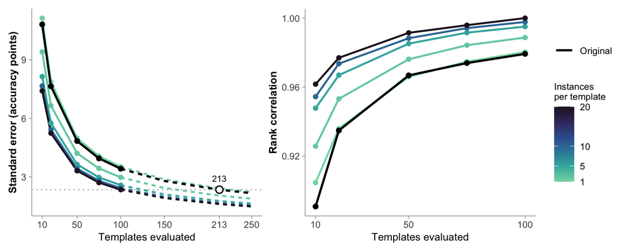

```r
## Palette matched to the ladder figure: mako, dark = more of the thing, which
## here is instances per template. A continuous scale rather than five discrete
## keys, since the budgets are a quantity and the point is the gradient.
##
## The original split is not a point on that scale -- it is a different question
## set, not a smaller budget -- so it is black, outside the gradient, and drawn
## last so it sits on top of the ramp rather than behind it.
ORIG_COL <- "black"

lay <- function(d, ylab) {
  sym <- d %>% filter(series != "Original") %>% arrange(n_inst, k)
  org <- d %>% filter(series == "Original") %>% arrange(k)
  list(
    sym = sym, org = org,
    base = ggplot(mapping = aes(k, y)) +
      scale_colour_viridis_c(option = "mako", begin = 0.1, end = 0.85, direction = -1,
                             name = "Instances\nper template",
                             breaks = c(1, 5, 10, 20), limits = c(1, 20)) +
      scale_linetype_manual(values = c(Original = "solid"), name = NULL) +
      scale_x_continuous(breaks = c(10, 50, 100, 150, 213, 250)) +
      labs(x = "Templates evaluated", y = ylab) +
      theme_minimal(base_size = 10) +
      ## No panel grid: the dotted reference line is the thing to read here.
      theme(panel.grid = element_blank(),
            axis.line = element_line(colour = "grey65", linewidth = 0.3),
            axis.ticks = element_line(colour = "grey65", linewidth = 0.3),
            axis.ticks.length = unit(2.5, "pt"),
            legend.position = "right", legend.key.height = unit(0.9, "lines"),
            legend.title = element_text(size = 8), legend.text = element_text(size = 8),
            axis.title.x = element_text(size = 9),
            axis.title.y = element_text(face = "bold", size = 9),
            plot.margin = margin(2, 4, 2, 2)))
}

L <- lay(d_se, "Standard error (accuracy points)")
p_left <- L$base +
  geom_hline(yintercept = sym100, linetype = "dotted", colour = "grey55", linewidth = 0.35) +
  geom_line(data = filter(L$sym, k <= 100), aes(colour = n_inst, group = n_inst), linewidth = 0.8) +
  geom_line(data = filter(L$sym, k >= 100), aes(colour = n_inst, group = n_inst),
            linewidth = 0.8, linetype = "22") +
  geom_point(data = filter(L$sym, k %in% KS), aes(colour = n_inst), size = 1.5) +
  ## original drawn after the ramp, so on top
  geom_line(data = filter(L$org, k <= 100), aes(linetype = "Original"),
            colour = ORIG_COL, linewidth = 0.9) +
  geom_line(data = filter(L$org, k >= 100), colour = ORIG_COL,
            linewidth = 0.9, linetype = "22") +
  geom_point(data = filter(L$org, k %in% KS), colour = ORIG_COL, size = 1.7) +
  annotate("point", x = 213, y = sym100, shape = 21, size = 2.4,
           colour = ORIG_COL, fill = "white", stroke = 0.8) +
  annotate("text", x = 213, y = sym100, label = "213", size = 2.6,
           colour = ORIG_COL, vjust = -1.3)

d_rho <- rank_res %>% group_by(series, k) %>% summarise(y = mean(rho), .groups = "drop") %>%
  mutate(n_inst = suppressWarnings(as.integer(sub("Symbolic, ", "", series))))
R2 <- lay(d_rho, "Rank correlation")
p_right <- R2$base +
  geom_line(data = R2$sym, aes(colour = n_inst, group = n_inst), linewidth = 0.8) +
  geom_point(data = R2$sym, aes(colour = n_inst), size = 1.5) +
  geom_line(data = R2$org, aes(linetype = "Original"), colour = ORIG_COL, linewidth = 0.9) +
  geom_point(data = R2$org, colour = ORIG_COL, size = 1.7) +
  coord_cartesian(xlim = c(10, 100))

p_ss <- patchwork::wrap_plots(p_left, p_right, nrow = 1, guides = "collect") &
  theme(legend.position = "right")

## Saved alongside the other paper figures so it can be \includegraphics'd.
dir.create("figures", showWarnings = FALSE)
ggsave("figures/fig_sample_size.pdf", p_ss, width = 8.0, height = 3.0, device = cairo_pdf)
ggsave("figures/fig_sample_size.png", p_ss, width = 8.0, height = 3.0, dpi = 200)
p_ss
```